# Doing Data Science: Case Study 2 - Forecasting Chulwalar Total Etel Exports

#### ARIMA modelling

The values for AIC, AICc and BIC should be minimised. We wil try a range of combinations.  
R uses the maximum likelihood estimation (MLE) in order to decide how good a certain model is. The parameters, which give the most likely model based on the given data, are chosen. Furthermore, R gives the log-likelihood, which should be maximised.

```r
print(summary(Model_ARIMA_1))
```

```
## Series: TotalAsIs
## ARIMA(0,1,0)
##
## sigma^2 estimated as 4.097e+11:  log likelihood=-1049.96
## AIC=2101.93   AICc=2101.99   BIC=2104.19
##
## Training set error measures:
##                    ME     RMSE      MAE       MPE     MAPE    MASE
## Training set 28628.79 635581.2 472471.7 -1.605296 16.44154 1.28785
##                    ACF1
## Training set -0.2573856
##                    ME     RMSE      MAE       MPE     MAPE    MASE
## Training set 28628.79 635581.2 472471.7 -1.605296 16.44154 1.28785
##                    ACF1
## Training set -0.2573856
```

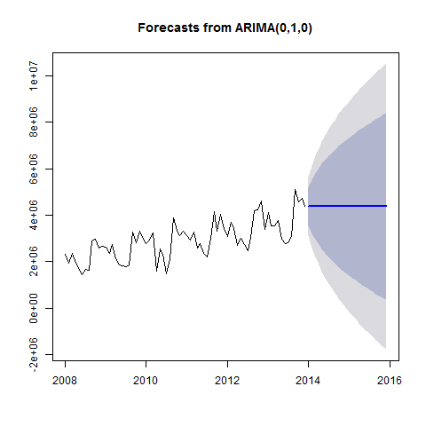

Figure 48

```r
#AIC=2101.93   AICc=2101.99   BIC=2104.19
```

```r
print(summary(Model_ARIMA_2))
```

```
## Series: TotalAsIs
## ARIMA(1,1,0)
##
## Coefficients:
##           ar1
##       -0.2531
## s.e.   0.1144
##
## sigma^2 estimated as 3.884e+11:  log likelihood=-1047.6
## AIC=2099.2   AICc=2099.38   BIC=2103.72
##
## Training set error measures:
##                    ME     RMSE      MAE       MPE     MAPE     MASE
## Training set 37287.11 614478.1 430163.6 -1.639433 15.09104 1.172528
##                     ACF1
## Training set -0.03792494
##                    ME     RMSE      MAE       MPE     MAPE     MASE
## Training set 37287.11 614478.1 430163.6 -1.639433 15.09104 1.172528
##                     ACF1
## Training set -0.03792494
```

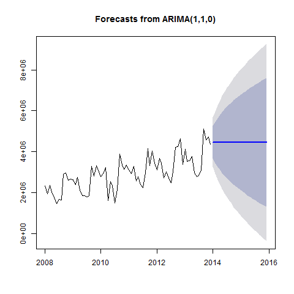

Figure 49

```r
#AIC=2099.2   AICc=2099.38   BIC=2103.72
```

```r
print(summary(Model_ARIMA_3))
```

```
## Series: TotalAsIs
## ARIMA(1,1,1)
##
## Coefficients:
##          ar1      ma1
##       0.5013  -0.8940
## s.e.  0.1225   0.0523
##
## sigma^2 estimated as 3.483e+11:  log likelihood=-1043.55
## AIC=2093.09   AICc=2093.45   BIC=2099.88
##
## Training set error measures:
##                    ME     RMSE    MAE       MPE     MAPE     MASE
## Training set 108896.1 577776.4 418339 0.1597019 14.59994 1.140297
##                     ACF1
## Training set -0.04946106
##                    ME     RMSE    MAE       MPE     MAPE     MASE
## Training set 108896.1 577776.4 418339 0.1597019 14.59994 1.140297
##                     ACF1
## Training set -0.04946106
```

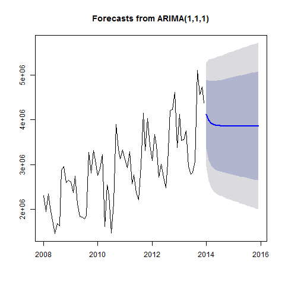

Figure 50

```r
#AIC=2093.09   AICc=2093.45   BIC=2099.88
```

[output not shown]

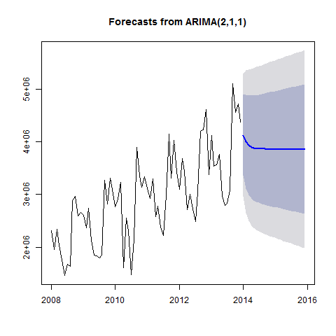

Figure 51

```r
#AIC=2095.08   AICc=2095.68   BIC=2104.13
```

[output not shown]

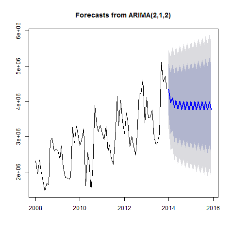

Figure 52

```r
#AIC=2091.07   AICc=2092   BIC=2102.39
```

```r
print(summary(Model_ARIMA_6))
```

```
## Series: TotalAsIs
## ARIMA(3,1,2)
##
## Coefficients:
##           ar1     ar2      ar3     ma1      ma2
##       -0.3893  0.5013  -0.1092  0.1083  -0.8830
## s.e.   0.1284  0.1385   0.1231  0.0569   0.0566
##
## sigma^2 estimated as 3.207e+11:  log likelihood=-1040.15
## AIC=2092.3   AICc=2093.61   BIC=2105.87
##
## Training set error measures:
##                    ME     RMSE      MAE       MPE     MAPE     MASE
## Training set 104678.5 542170.4 409442.9 0.3156703 14.41613 1.116048
##                     ACF1
## Training set -0.03533504
##                    ME     RMSE      MAE       MPE     MAPE     MASE
## Training set 104678.5 542170.4 409442.9 0.3156703 14.41613 1.116048
##                     ACF1
## Training set -0.03533504
```

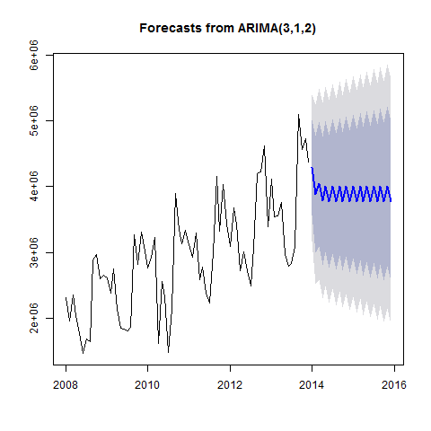

Figure 53

```r
#AIC=2092.3   AICc=2093.61   BIC=2105.87
```

```r
print(summary(Model_ARIMA_7))
```

```
## Series: TotalAsIs
## ARIMA(3,1,3)
##
## Coefficients:
##           ar1      ar2     ar3     ma1     ma2      ma3
##       -0.3899  -0.3992  0.5784  0.0121  0.1473  -0.8863
## s.e.   0.2719   0.2546  0.1245  0.5756  0.2820   0.6757
##
## sigma^2 estimated as 3.243e+11:  log likelihood=-1040.01
## AIC=2094.03   AICc=2095.81   BIC=2109.87
##
## Training set error measures:
##                    ME   RMSE      MAE       MPE     MAPE     MASE
## Training set 98929.36 541073 383116.9 0.2717968 13.13481 1.044289
##                     ACF1
## Training set 0.006450566
##                    ME   RMSE      MAE       MPE     MAPE     MASE
## Training set 98929.36 541073 383116.9 0.2717968 13.13481 1.044289
##                     ACF1
## Training set 0.006450566
```

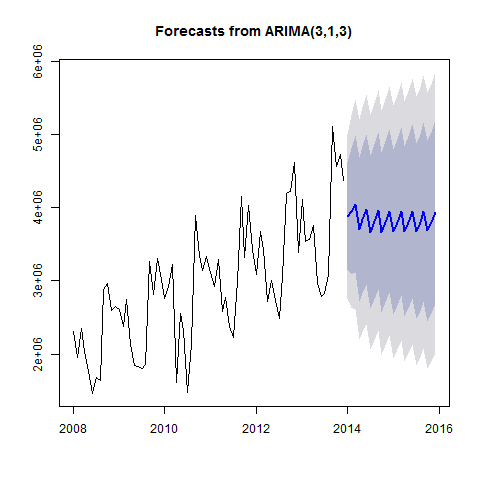

Figure 54

```r
#AIC=2094.03   AICc=2095.81   BIC=2109.87
```

```r
print(summary(Model_ARIMA_8))
```

```
## Series: TotalAsIs
## ARIMA(3,1,1)
##
## Coefficients:
##          ar1     ar2      ar3      ma1
##       0.4861  0.0501  -0.0876  -0.8861
## s.e.  0.1284  0.1321   0.1224   0.0558
##
## sigma^2 estimated as 3.557e+11:  log likelihood=-1043.29
## AIC=2096.57   AICc=2097.5   BIC=2107.89
##
## Training set error measures:
##                    ME     RMSE      MAE       MPE     MAPE     MASE
## Training set 112288.1 575349.1 416026.3 0.2735252 14.58788 1.133993
##                     ACF1
## Training set -0.06722377
##                    ME     RMSE      MAE       MPE     MAPE     MASE
## Training set 112288.1 575349.1 416026.3 0.2735252 14.58788 1.133993
##                     ACF1
## Training set -0.06722377
```

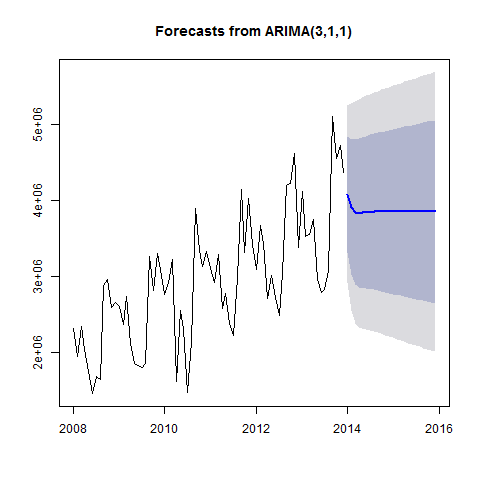

Figure 55

```r
#AIC=2096.57   AICc=2097.5   BIC=2107.89
```

```r
print(summary(Model_ARIMA_9))
```

```
## Series: TotalAsIs
## ARIMA(3,1,2)
##
## Coefficients:
##           ar1     ar2      ar3     ma1      ma2
##       -0.3893  0.5013  -0.1092  0.1083  -0.8830
## s.e.   0.1284  0.1385   0.1231  0.0569   0.0566
##
## sigma^2 estimated as 3.207e+11:  log likelihood=-1040.15
## AIC=2092.3   AICc=2093.61   BIC=2105.87
##
## Training set error measures:
##                    ME     RMSE      MAE       MPE     MAPE     MASE
## Training set 104678.5 542170.4 409442.9 0.3156703 14.41613 1.116048
##                     ACF1
## Training set -0.03533504
##                    ME     RMSE      MAE       MPE     MAPE     MASE
## Training set 104678.5 542170.4 409442.9 0.3156703 14.41613 1.116048
##                     ACF1
## Training set -0.03533504
```

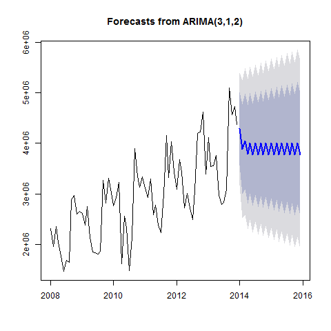

Figure 56

```r
#AIC=2092.3   AICc=2093.61   BIC=2105.87
```

```r
print(summary(Model_ARIMA_10))
```

```
## Series: TotalAsIs
## ARIMA(1,1,3)
##
## Coefficients:
##          ar1      ma1     ma2      ma3
##       0.4527  -0.8779  0.0965  -0.1023
## s.e.  0.2410   0.2408  0.2460   0.1621
##
## sigma^2 estimated as 3.567e+11:  log likelihood=-1043.34
## AIC=2096.69   AICc=2097.61   BIC=2108
##
## Training set error measures:
##                    ME   RMSE      MAE       MPE     MAPE     MASE
## Training set 108260.8 576125 411814.8 0.1681833 14.39459 1.122513
##                     ACF1
## Training set -0.02687555
##                    ME   RMSE      MAE       MPE     MAPE     MASE
## Training set 108260.8 576125 411814.8 0.1681833 14.39459 1.122513
##                     ACF1
## Training set -0.02687555
```

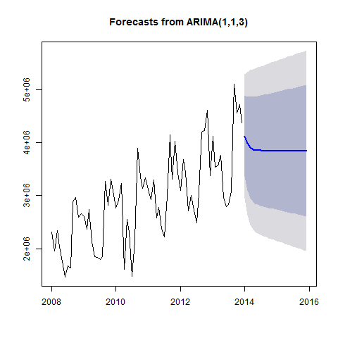

Figure 57

```r
#AIC=2096.69   AICc=2097.61   BIC=2108
```

```r
print(summary(Model_ARIMA_11))
```

```
## Series: TotalAsIs
## ARIMA(2,1,3)
##
## Coefficients:
##           ar1      ar2     ma1      ma2      ma3
##       -1.1981  -0.1982  1.1439  -0.6940  -0.8420
## s.e.   0.1350   0.1350  0.1239   0.1394   0.1099
##
## sigma^2 estimated as 2.64e+11:  log likelihood=-1036.61
## AIC=2085.22   AICc=2086.53   BIC=2098.8
##
## Training set error measures:
##                 ME   RMSE      MAE       MPE     MAPE     MASE        ACF1
## Training set 96418 491927 381028.7 0.4152085 13.44772 1.038597 0.003938262
##                 ME   RMSE      MAE       MPE     MAPE     MASE        ACF1
## Training set 96418 491927 381028.7 0.4152085 13.44772 1.038597 0.003938262
```

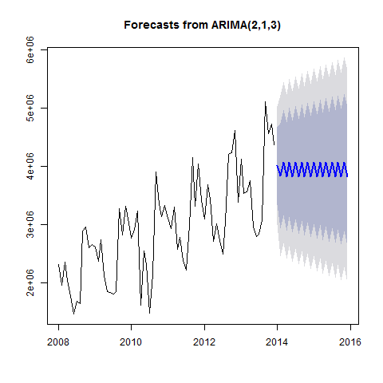

Figure 58

```r
#AIC=2085.22   AICc=2086.53   BIC=2098.8
```

```r
print(summary(Model_ARIMA_12))
```

```
## Series: TotalAsIs
## ARIMA(2,2,3)
##
## Coefficients:
##           ar1     ar2      ma1      ma2     ma3
##       -0.4575  0.5423  -0.9992  -0.9842  0.9938
## s.e.   0.1097  0.1097   0.0600   0.0468  0.0596
##
## sigma^2 estimated as 2.933e+11:  log likelihood=-1026.69
## AIC=2065.39   AICc=2066.72   BIC=2078.88
##
## Training set error measures:
##                    ME     RMSE      MAE       MPE     MAPE     MASE
## Training set 32207.69 514572.7 390086.2 -1.782274 13.95983 1.063286
##                   ACF1
## Training set 0.0523144
##                    ME     RMSE      MAE       MPE     MAPE     MASE
## Training set 32207.69 514572.7 390086.2 -1.782274 13.95983 1.063286
##                   ACF1
## Training set 0.0523144
```

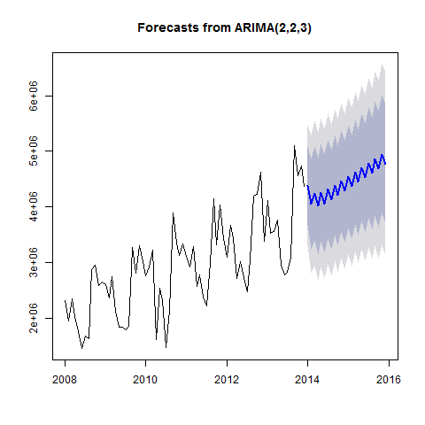

Figure 59

```r
#AIC=2065.39   AICc=2066.72   BIC=2078.88
```

```r
print(summary(Model_ARIMA_13))
```

```
## Series: TotalAsIs
## ARIMA(2,3,2)
##
## Coefficients:
##           ar1      ar2      ma1     ma2
##       -0.2556  -0.0955  -1.9949  0.9998
## s.e.   0.1213   0.1203   0.0568  0.0565
##
## sigma^2 estimated as 4.154e+11:  log likelihood=-1025.64
## AIC=2061.27   AICc=2062.22   BIC=2072.44
##
## Training set error measures:
##                     ME     RMSE    MAE       MPE     MAPE     MASE
## Training set -18789.17 612404.9 442164 -3.108129 15.40378 1.205238
##                    ACF1
## Training set -0.0160389
##                     ME     RMSE    MAE       MPE     MAPE     MASE
## Training set -18789.17 612404.9 442164 -3.108129 15.40378 1.205238
##                    ACF1
## Training set -0.0160389
```

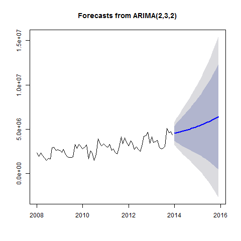

Figure 60

```r
#AIC=2061.27   AICc=2062.22   BIC=2072.44
```

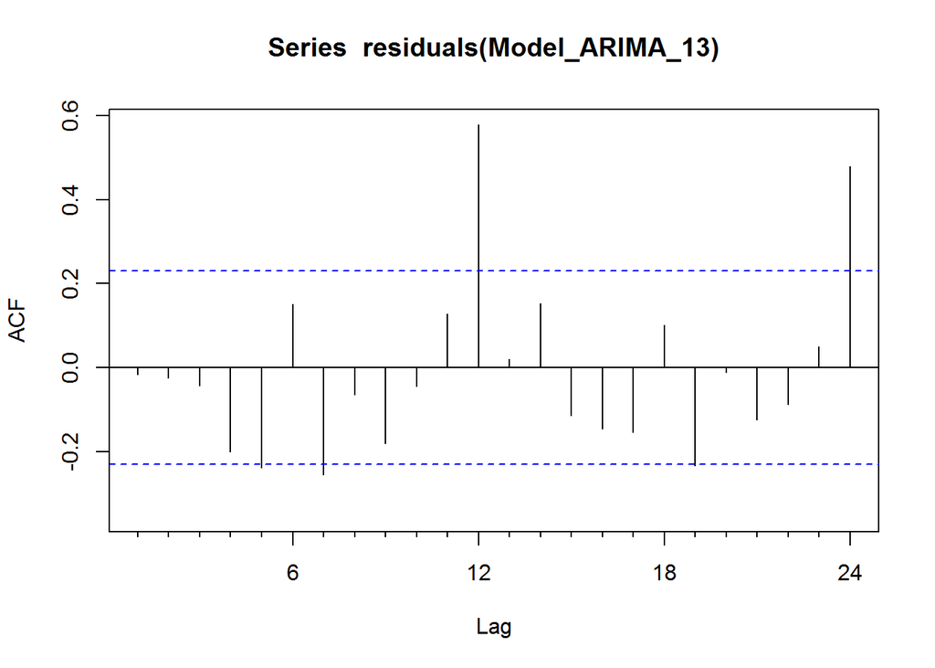

```
##
## Autocorrelations of series 'residuals(Model_ARIMA_13)', by lag
##
##      0      1      2      3      4      5      6      7      8      9
##  1.000 -0.016 -0.025 -0.043 -0.201 -0.240  0.151 -0.256 -0.065 -0.181
##     10     11     12     13     14     15     16     17     18     19
## -0.044  0.128  0.578  0.020  0.153 -0.115 -0.146 -0.154  0.100 -0.234
##     20     21     22     23     24
## -0.013 -0.125 -0.088  0.049  0.479
```

```r
print(Acf(residuals(Model_ARIMA_13)))
```

```r
print(Box.test(residuals(Model_ARIMA_13), lag=12, fitdf=4, type="Ljung"))
```

```
##
##  Box-Ljung test
##
## data:  residuals(Model_ARIMA_13)
## X-squared = 49.513, df = 8, p-value = 5.068e-08
```

The Ljung-Box Test has H0: The data are independently distributed und Ha: The data are not independently distributed.  
Just like the remainder showed before, there is a definite coherence.